# Resubmission Graphs

RAZ

January 8, 2018

BUSCO Analysis

You can see from this that the “Full” transcriptome retains a lot more BUSCOs (i.e. conserved genes) than our other three assemblies, so I’ve done all the analyses on this one. The first set of graphs and Venn Diagrams is what we’ve seen before, but I omitted the MA plots for Large vs Small females. I’m not sure that’s even a very informative set of graphs, to be honest.

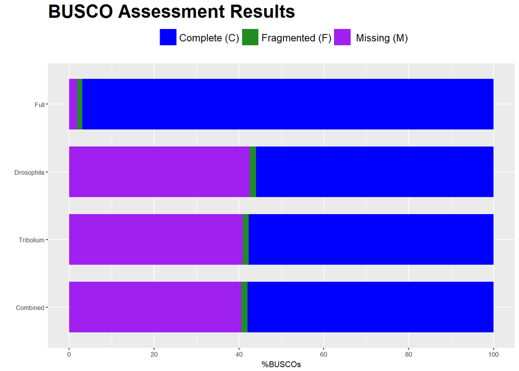

# DESeq Analysis

Nutritionally Sensitive MA plots. I.e. DE in large vs small males. Theres 187 gens DE in horns, 41 DE genes in Thoracic horns, 13 in Wings, and 25 in genitals. Almost our predictions, but genitals have more DE than wings.

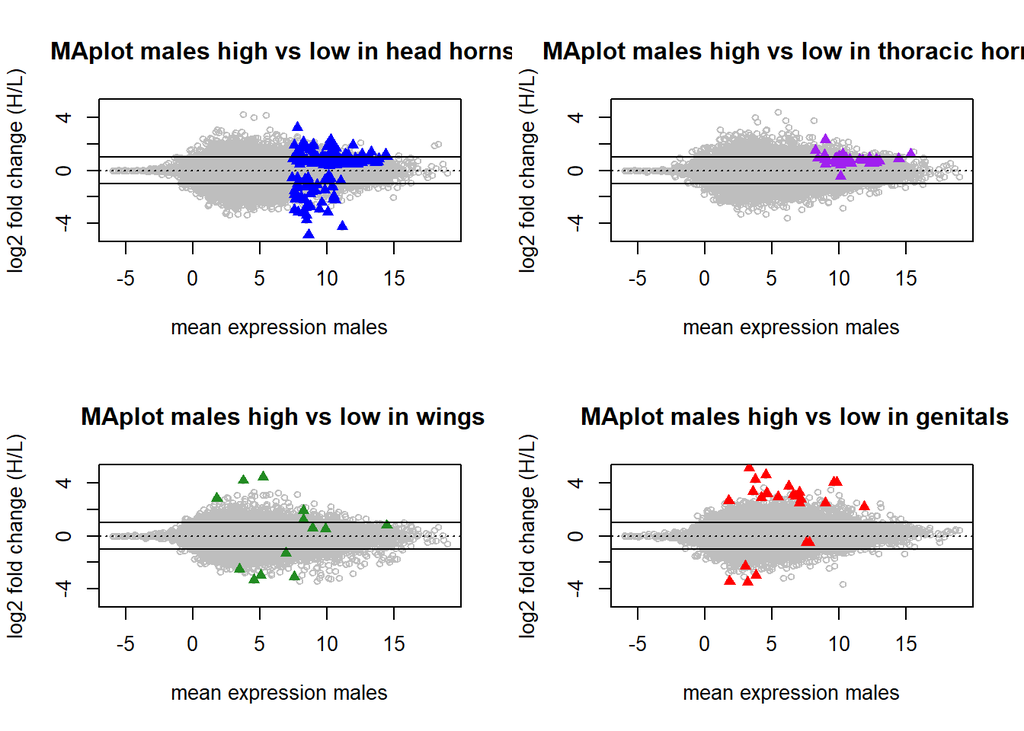

Nutritionally Sensitive Venn diagram. The genes DE in each tissue that overlap. As the initial draft says, these are pretty consistent. Horns share with horns but there isn’t a LOT of overlap.

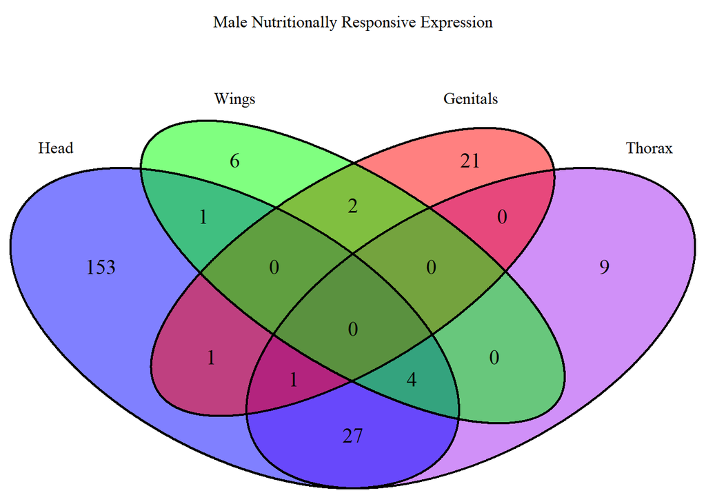

Sexually Dimorphic Gene expression. We have 4031 seqs DE by sex in horns, 525 seqs DE by sex in Th horns, and 157 seqs DE by sex in wings, confirming our predictions.

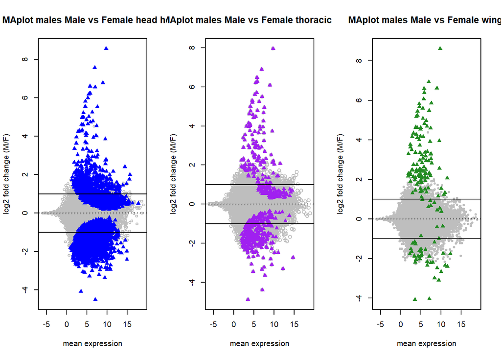

Sexually Dimorphic Venns. There isn’t a LOT of overlap in DE genes based on sexual dimorphism. Head horns and Thoracic horns share the greatest number of DE genes, but there’s a core of 111 genes DE in all three tissues.

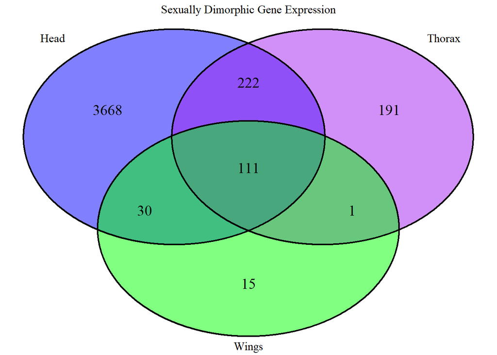

Overlap between NR geneset and SD Geneset. I haven’t had time to clean this up, but if we take ALL the genes differentially expressed as a result of sexual dimorphism and ALL the genes differentially expressed as a result of nutritional sensitivity, about half of the nutrition genes are also DE in the SD genes (approx 100 genes)

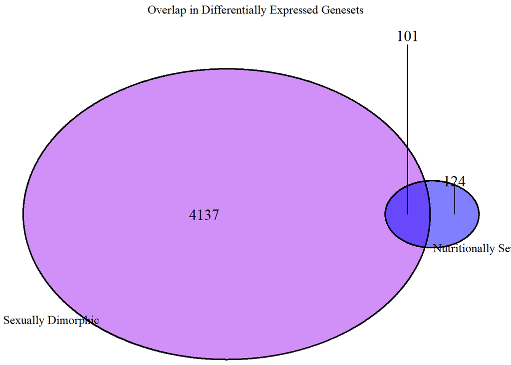

This is simply a table of the Correlation (r) and Alpha values, with p-values.

```r
correlation.alphas
```

```
##         value  estimate      y.min       mid     y.max      comparison
## 1  vector.cor 0.5192516 0.24044473 0.2741140 0.3012481     SD.mvf.horn
## 3   vec.alpha 1.8809844 0.99455550 1.0384666 1.0810232     SD.mvf.horn
## 5  vector.cor 0.5399124 0.12305217 0.2758627 0.3970926     NR.mvf.horn
## 7   vec.alpha 1.4121387 0.86163412 1.0266122 1.2355952     NR.mvf.horn
## 9  vector.cor 0.6998981 0.32253055 0.4660351 0.5717533    NR.horn.wing
## 11  vec.alpha 1.5400519 0.76049789 0.8796796 0.9970796    NR.horn.wing
## 13 vector.cor 0.3033667 0.03594846 0.2063512 0.3546215 NR.horn.genital
## 15  vec.alpha 1.2235231 0.73293635 0.8692320 0.9958031 NR.horn.genital
## 17 vector.cor 0.6443312 0.50621817 0.5348436 0.5573927      sd.horn.th
## 19  vec.alpha 1.0423734 0.94884428 0.9780062 1.0029217      sd.horn.th
## 21 vector.cor 0.7900493 0.39743707 0.5360299 0.6330200      nr.horn.th
## 23  vec.alpha 1.5119331 0.85166072 0.9774793 1.0954237      nr.horn.th
##    geneset group     pvalue
## 1       SD     1 0.00009999
## 3       SD     1 0.00009999
## 5       NR     1 0.00019998
## 7       NR     1 0.00669933
## 9       NR     2 0.00009999
## 11      NR     2 0.00009999
## 13      NR     2 0.14228577
## 15      NR     2 0.00019998
## 17      SD     3 0.00009999
## 19      SD     3 0.00019998
## 21      NR     3 0.00009999
## 23      NR     3 0.00009999
```

Plot the Results. Same as we did last time. Results match what we found with the reduced transcriptomes in the initial draft. The x-axis in the correlation plot is the same as the Alpha plot below it.

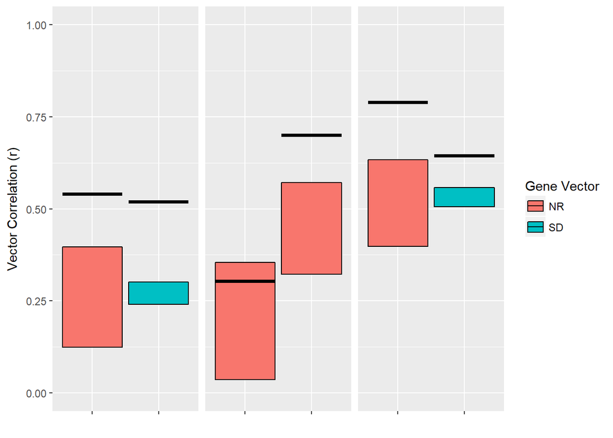

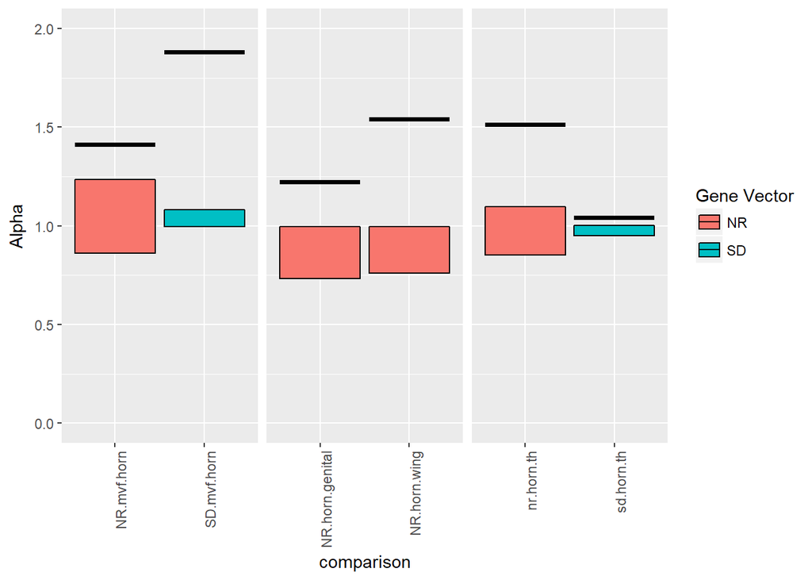

In the plot below, I computed the mean and SD for each gene in each group (i.e. the mean and SD for all the genes from large, male horns). I used either the differentially expressed genes by size, or all the genes in total. This is supposed to try and respond to our reviewer comment about “whether or not we simply captured the genes that are the most variable”. As you can see, the SD of the DE genes is a bit more spread out than all of the genes, but the range on the SD is still pretty small. I’m still not sure I made this graph correctly, Ian please check this!

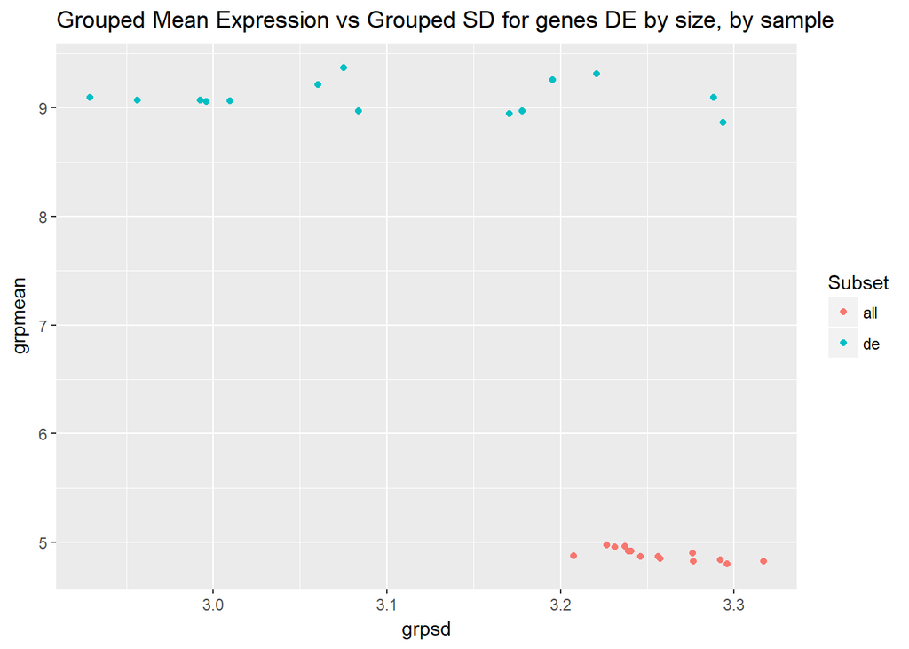

```r
rld <- rlog(all.dds)
rld.assay <-as.data.frame(assay(rld))


##lg male hd horn sd

degenes.sd<-as.data.frame(rld.assay %>%
  rownames_to_column('gene')%>%
  filter(gene %in% de.size)%>%
  column_to_rownames('gene')%>%
  summarise_all(., sd)%>%
  gather(sample, sd))

degenes.mean<-rld.assay %>%
  rownames_to_column('gene')%>%
  filter(gene %in% de.size)%>%
  column_to_rownames('gene')%>%
  summarise_all(., mean)%>%
  gather(sample, mean)%>%
  dplyr::select(., 2)
degenes.sd.mean<-cbind(degenes.sd, degenes.mean)
degenes.sd.mean<-degenes.sd.mean%>%
  separate(., sample, sep="_", c("Number", "size", "sex", "tissue"), remove=TRUE)%>%
  dplyr::select(., -Number)



allgenes.mean<-rld.assay%>%
  summarise_all(., mean)%>%
  gather(sample, mean)%>%
  dplyr::select(., 2)

allgenes.sd<-rld.assay%>%
  summarise_all(., sd)%>%
  gather(sample, sd)

allgenes.sd.mean<- cbind(allgenes.sd, allgenes.mean)
allgenes.sd.mean<-allgenes.sd.mean%>%
  separate(., sample, sep="_", c("Number", "size", "sex", "tissue"), remove=TRUE)%>%
  dplyr::select(., -Number)


summed.degenes<-group_by(degenes.sd.mean, size, sex, tissue) %>% summarise_all(funs(cum.mean=mean)) %>% dplyr::rename(grpmean=mean_cum.mean, grpsd=sd_cum.mean)
summed.allgenes<-group_by(allgenes.sd.mean, size, sex, tissue) %>% summarise_all(funs(cum.mean=mean)) %>% dplyr::rename(grpmean=mean_cum.mean, grpsd=sd_cum.mean)


ggplot(summed.degenes, aes(x=grpsd, y=grpmean))+
  geom_point(aes(color="de"))+
  geom_point(data=summed.allgenes, aes(x=grpsd, y=grpmean, color="all"))+
  ggtitle("Grouped Mean Expression vs Grouped SD for genes DE by size, by sample")+
  scale_color_discrete("Subset")
```

# plots for Reaction Norms

I like this graph, it seems to show nearly consistent expression of nutritionally sensitive genes across tissue types.

So what I did is take the genes DE by nutrition, and calculate the mean expression value for each gene across each tissue type. I used the absolute value of the log2 of the normalized counts, plus a 1/2 pseudocount. Then I took the mean of that value for each tissue for genes differentially expressed by size, and graphed how each gene changed across each of the four tissue types.

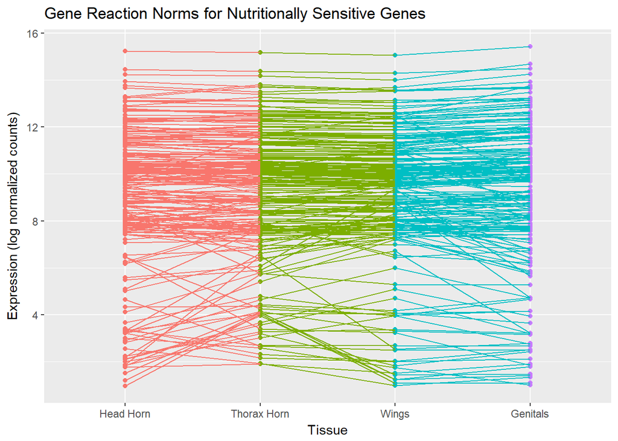

This graph is….not my favorite. I did the same as above, but I don’t know how to make it look better or be more informative. It’s just impossible to parse due to how many genes there are. Ideas for how to subset this would be nice!

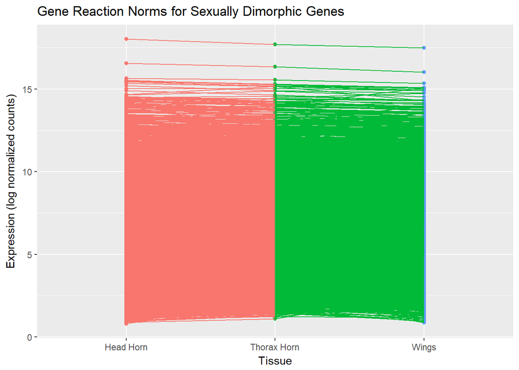

The graphs below are an attempt to also address the “interaction” effects our reviewers were curious about. I’m not sure whether these address their concerns, and am going to lean on Ian.

```r
summary(results(horn.dds, alpha=0.05))
```

```
##
## out of 48586 with nonzero total read count
## adjusted p-value < 0.05
## LFC > 0 (up)     : 142, 0.29%
## LFC < 0 (down)   : 106, 0.22%
## outliers [1]     : 666, 1.4%
## low counts [2]   : 2767, 5.7%
## (mean count < 3)
## [1] see 'cooksCutoff' argument of ?results
## [2] see 'independentFiltering' argument of ?results
```

```r
summary(results(th.dds, alpha=0.05))
```

```
##
## out of 48580 with nonzero total read count
## adjusted p-value < 0.05
## LFC > 0 (up)     : 242, 0.5%
## LFC < 0 (down)   : 126, 0.26%
## outliers [1]     : 630, 1.3%
## low counts [2]   : 6439, 13%
## (mean count < 6)
## [1] see 'cooksCutoff' argument of ?results
## [2] see 'independentFiltering' argument of ?results
```

```r
summary(results(win.dds, alpha=0.05))
```

```
##
## out of 48557 with nonzero total read count
## adjusted p-value < 0.05
## LFC > 0 (up)     : 106, 0.22%
## LFC < 0 (down)   : 89, 0.18%
## outliers [1]     : 679, 1.4%
## low counts [2]   : 5486, 11%
## (mean count < 4)
## [1] see 'cooksCutoff' argument of ?results
## [2] see 'independentFiltering' argument of ?results
```

Here’s a Venn diagram of the overlap in DE genes in the interactions

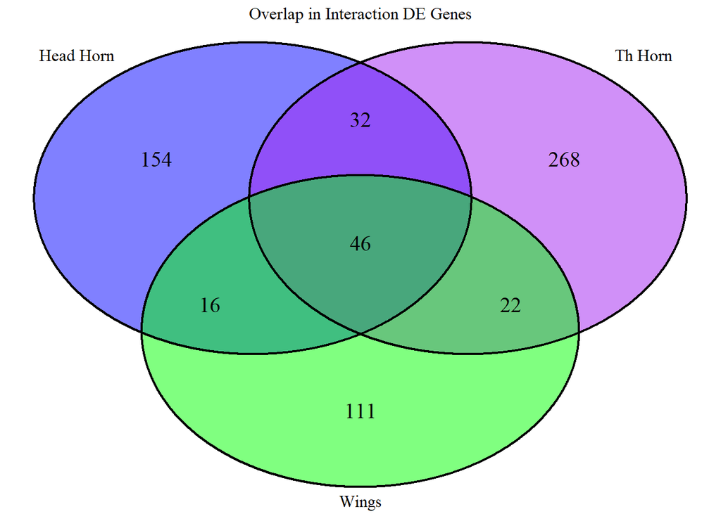

The code below is the reaction norm of the intraction terms

```r
hi.counts <-t(abs(log2((counts(horn.dds[rownames(horn.de), ],
                         normalized=TRUE, replaced=FALSE)+0.5)))) %>%
  merge(colData(horn.dds), ., by="row.names") %>%
  gather(gene, expression, (ncol(.)-length(rownames(horn.de))+1):ncol(.)) %>%
  rename(samples=Row.names) %>%
  mutate(samples=as.character(samples))%>%
  mutate(gene=factor(gene))



ti.counts <- t(abs(log2((counts(th.dds[rownames(th.de), ],
                                normalized=TRUE, replaced=FALSE)+0.5)))) %>%
  merge(colData(th.dds), ., by="row.names") %>%
  gather(gene, expression, (ncol(.)-length(rownames(th.de))+1):ncol(.))%>%
  rename(samples=Row.names) %>%
  mutate(samples=as.character(samples))%>%
  mutate(gene=factor(gene))



wi.counts <- t(abs(log2((counts(win.dds[rownames(win.de), ],
                                normalized=TRUE, replaced=FALSE)+0.5)))) %>%
  merge(colData(win.dds), ., by="row.names") %>%
  gather(gene, expression, (ncol(.)-length(rownames(win.de))+1):ncol(.))%>%
  rename(samples=Row.names) %>%
  mutate(samples=as.character(samples))%>%
  mutate(gene=factor(gene))




interact.counts <- bind_rows(list(horn = hi.counts, thx = ti.counts, wing=wi.counts), .id = "compare")
```

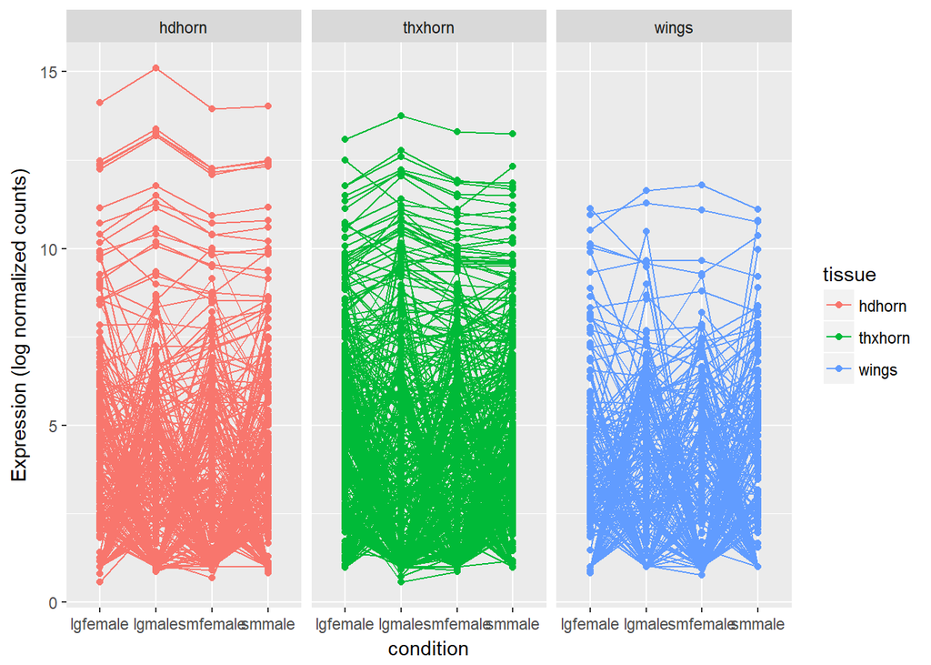

```r
##need to work on this below
ggplot((group_by(interact.counts, gene, sex, size, tissue) %>% dplyr::summarise(mean=mean(expression)) %>% unite("condition", size , sex, sep="")), aes(x=condition, y=mean, color=tissue))+
  geom_point()+geom_line(aes(group=interaction(gene)))+
  #scale_x_discrete(labels=c("Head Horn", "Thorax Horn", "Wings"))+
  labs(x="condition",
       y="Expression (log normalized counts)")+
  facet_grid(~tissue)
```

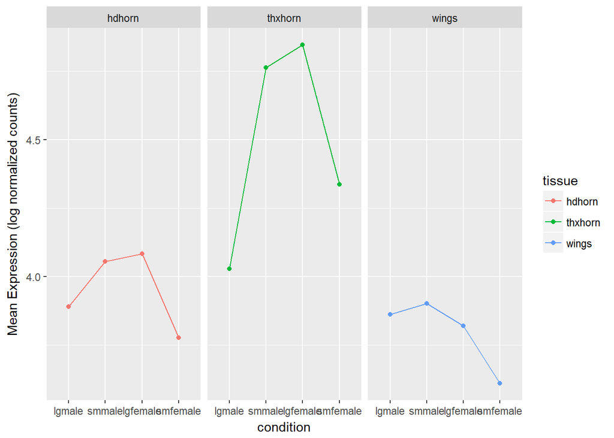

```r
ggplot((group_by(interact.counts, gene, sex, size, tissue) %>% dplyr::summarise(mean=mean(expression)) %>% unite("condition", size , sex, sep="") %>% group_by(tissue, condition)%>% dplyr::summarise(tissuemean=mean(mean)) %>% mutate(condition = factor(condition, levels=c("lgmale", "smmale", "lgfemale", "smfemale")))), aes(x=condition, y=tissuemean, color=tissue))+
  geom_point()+geom_line(aes(group=interaction(tissue)))+
  #scale_x_discrete(labels=c("Head Horn", "Thorax Horn", "Wings"))+
  labs(x="condition",
       y="Mean Expression (log normalized counts)")+
  facet_grid(~tissue)
```

```r
##
```

```r
horn.vsall<-results(all.dds,
contrast=list("grouphdhornlgmale", c("grouphdhornsmmale","grouphdhornsmfemale","grouphdhornlgfemale")), listValues=c(1,-1/3), alpha=0.05)

summary(horn.vsall)
```

```
##
## out of 48704 with nonzero total read count
## adjusted p-value < 0.05
## LFC > 0 (up)     : 1243, 2.6%
## LFC < 0 (down)   : 1486, 3.1%
## outliers [1]     : 606, 1.2%
## low counts [2]   : 1664, 3.4%
## (mean count < 3)
## [1] see 'cooksCutoff' argument of ?results
## [2] see 'independentFiltering' argument of ?results
```

```r
thx.vsall<-results(all.dds,
contrast=list("groupthxhornlgmale", c("groupthxhornsmmale","groupthxhornsmfemale","groupthxhornlgfemale")), listValues=c(1,-1/3), alpha=0.05)

summary(thx.vsall)
```

```
##
## out of 48704 with nonzero total read count
## adjusted p-value < 0.05
## LFC > 0 (up)     : 278, 0.57%
## LFC < 0 (down)   : 258, 0.53%
## outliers [1]     : 606, 1.2%
## low counts [2]   : 781, 1.6%
## (mean count < 2)
## [1] see 'cooksCutoff' argument of ?results
## [2] see 'independentFiltering' argument of ?results
```

```r
wings.vsall<-results(all.dds,
contrast=list("groupwingslgmale", c("groupwingssmmale","groupwingssmfemale","groupwingslgfemale")), listValues=c(1,-1/3), alpha=0.05)

summary(wings.vsall)
```

```
##
## out of 48704 with nonzero total read count
## adjusted p-value < 0.05
## LFC > 0 (up)     : 88, 0.18%
## LFC < 0 (down)   : 38, 0.078%
## outliers [1]     : 606, 1.2%
## low counts [2]   : 0, 0%
## (mean count < 0)
## [1] see 'cooksCutoff' argument of ?results
## [2] see 'independentFiltering' argument of ?results
```

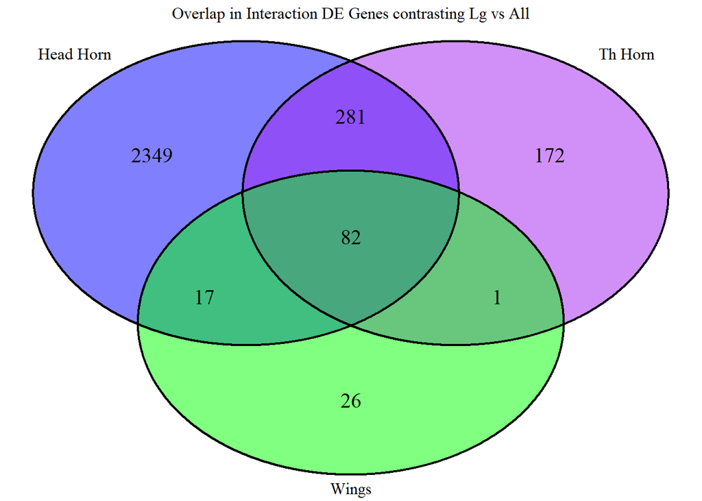